[output not shown]

## Introduction

In high-density metropolitan areas like Toronto, assessing how specific layout configurations influence rental pricing provides valuable insight into market structure and housing affordability. This study examines the relationship between apartment layout characteristics and monthly rent across the city. Specifically, we use multiple linear regression to evaluate how the number of bedrooms, bathrooms, and their interaction effects predict continuous rental prices. To test predictive validity further, we apply binary logistic regression using the same structural features to determine whether a listing classifies as a high-value property. By comparing main-effects and interaction models across both regression frameworks, we assess the overall explanatory power of layout features in Toronto’s housing market.

## Data Description

### Source and Collection

The dataset for this study was retrieved from a public Kaggle repository titled [Toronto Apartment Rental Price](https://www.kaggle.com/datasets/rajacsp/toronto-apartment-price/data), compiled by independent creator Raja CSP. According to the dataset documentation, the listings were aggregated and scraped from local rental websites active across Toronto in 2018.

### Structure and Format

The study utilizes Version 3 of the dataset, stored as a single comma-separated values file (`Toronto_apartment_rentals_2018.csv`) with a total file size of 94.97 KB. The raw file contains $N = 1,124$ observational rows across 7 attribute columns, where each row corresponds to a unique apartment listing. There are no missing values in any columns in the raw data.

The total number of rows in the original dataset is 1,124. There are no missing values in any columns.

During data cleaning, we removed 308 duplicates which likely occurred because the data came from multiple sources. We also removed 5 rows with unusual values for `price` ($65/month, $99/month, $99/month, $36,900/month, $535,000/month). These outliers may skew our results so we decided to remove them. The sample size is now `n = 811`.

## Exploratory Data Analysis

Before modeling, we want to find out more about the data.

We first examine each variable individually. Below are the sample’s summary statistics of each variable.

| Variable | Mean | SD | Min | Max |
| --- | --- | --- | --- | --- |
| bathroom | 1.24 | 0.44 | 1.00 | 3.00 |
| bedroom | 1.37 | 0.57 | 1.00 | 3.00 |
| den | 0.15 | 0.36 | 0.00 | 1.00 |
| lat | 43.71 | 0.69 | 42.99 | 56.13 |
| long | -79.50 | 1.84 | -114.08 | -73.58 |
| price | 2185.71 | 787.36 | 150.00 | 9750.00 |

We also visualize the distribution of each variable individually.

To visualize the distribution of `price`, we plot a histogram.

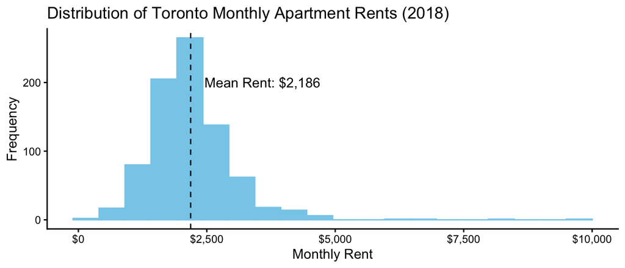

Next, we view the frequencies of each discrete value of `bedroom`, `bathroom`, and `den`.

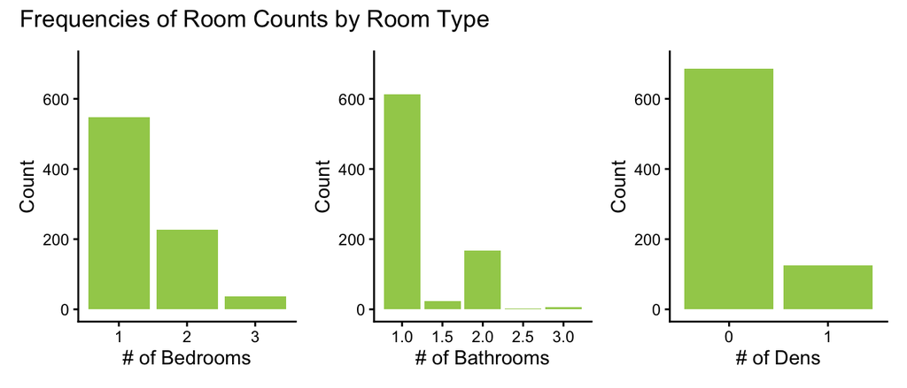

Next, we examine possible relationships between variables. Below are boxplots of `price` split by `bedroom`, `bathroom`, and `den` counts in order to see how `price`’s distribution varies by each of these 3 apartment characteristics.

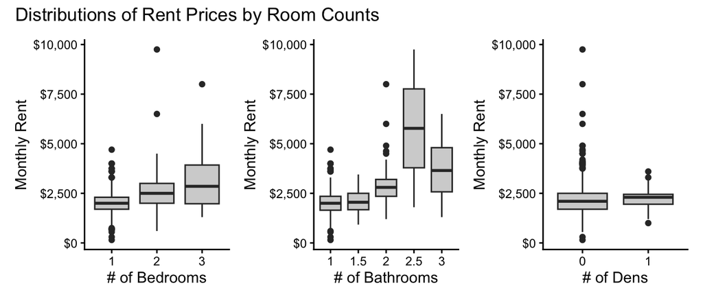

We’re also curious about the correlations between the variables so we plot (the upper triangle of) a correlation matrix.

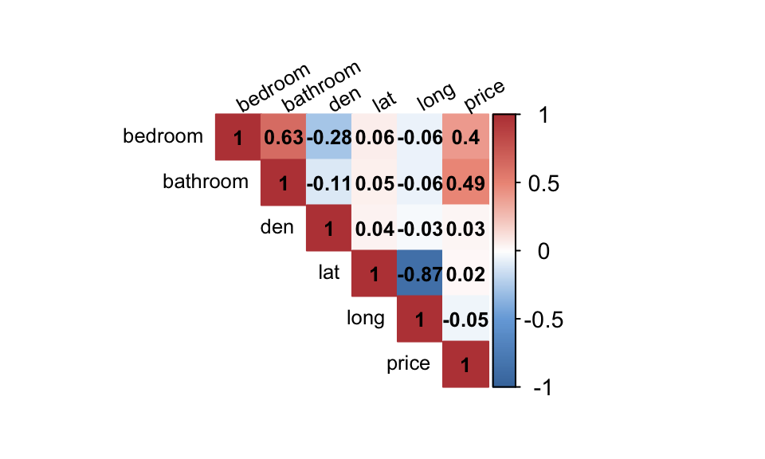

## Models

Now that we have processed our data, we can consider models that can predict rental price based on our other variables. In the previous section, we narrowed down the variables we can use as predictors to number of bedrooms and number of bathrooms. To make use of these predictors, we have two options: a multiple linear regression and a multiple logistic regression.

### Multiple Linear Regression

A multiple linear regression model model generates predictions as a straight line with a slope and intercept.

When making a multiple linear regression model, one of the first things to consider is whether or not interaction exists between covariates. If there is interaction, then the slope of the prediction line will be different depending on the value of the covariates; if not the slope is constant. This can be checked with hypothesis testing, something which can be checked by creating a model with interaction in R and checking the model’s statistics.

Results with interaction:

| term | estimate | std.error | statistic | p.value | conf.low | conf.high |
| --- | --- | --- | --- | --- | --- | --- |
| (Intercept) | 1609.69 | 238.10 | 6.76 | 0.00 | 1142.32 | 2077.07 |
| bedroom | -131.33 | 141.90 | -0.93 | 0.35 | -409.86 | 147.20 |
| bathroom | 215.80 | 203.38 | 1.06 | 0.29 | -183.42 | 615.02 |
| bedroom:bathroom | 263.75 | 102.30 | 2.58 | 0.01 | 62.94 | 464.56 |

Results without interaction:

| term | estimate | std.error | statistic | p.value | conf.low | conf.high |
| --- | --- | --- | --- | --- | --- | --- |
| (Intercept) | 1026.44 | 74.50 | 13.78 | 0 | 880.20 | 1172.68 |
| bedroom | 206.60 | 54.54 | 3.79 | 0 | 99.53 | 313.66 |
| bathroom | 707.66 | 70.73 | 10.01 | 0 | 568.83 | 846.49 |

To ensure that our linear model is appropriate for the data, we need to run some model diagnostics in the form of a residual and Q-Q plot.

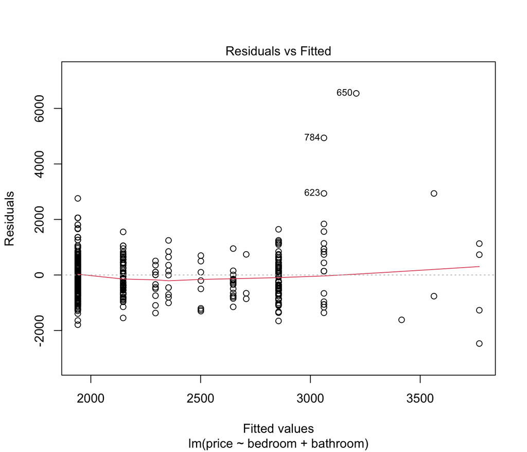

For a linear model to be appropriate, the error around the trend/prediction line should be consistent and normally distributed. Residual plots offer a convenient visual representation of this error. In a residual plot, error should be distributed normally and evenly around a horizontal line at y = 0. As you can see in the plot above, because our predictors are categorical, the data points are not continuously distributed, making the plot somewhat messy to look at. It shows that while the error approximately follows a normal distribution distribution, but with larger variance around certain areas in the x axis, meaning the variance is not perfectly consistent.

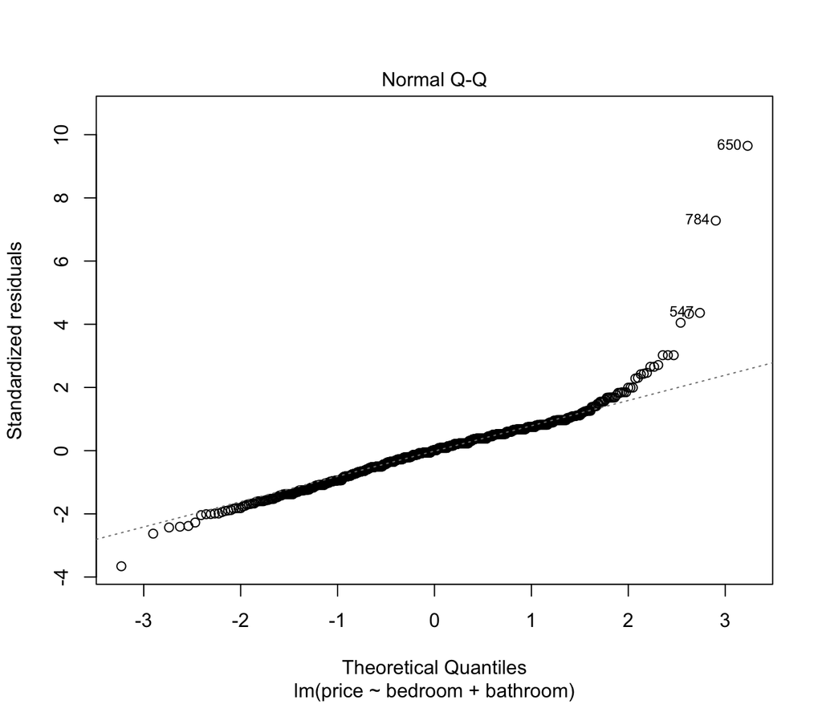

Another way of checking the distributon of the error is a Q-Q plot. If the error is normally distributed with equal variance, then a Q-Q plot will show all data points distributed along a straight, sloped line wherein X = Y. The Q-Q plot of our linear model shows the data following this line for the most part, but diverging at the beginning and the end, implying that our model has more extreme data than can be expected under a true normal distribution (Clay, 2015). Applying transformations to the model, such as log transformation and predicting the square root of the response variable, were unsuccesful in creating a more favourable distribution.

While our diagnostics reveal that our data may not be perfectly suited for a linear analysis, this is not uncommon for observed data. It is our belief that our model is still useful for making predictions.

### Multiple Logistic Regression

A multiple logistic regression model is used to make predictions for a categorical response variable. To make use of such a model, we converted our response variable (price) into a categorical one by splitting it into two categories for rent above and below the mean value. Thus, our model will be predicting whether a property has above or below average rent, rather than a specific value.

Once again, we need to begin by checking for interaction between predictors.

Results with interaction:

| term | estimate | std.error | statistic | p.value | conf.low | conf.high |
| --- | --- | --- | --- | --- | --- | --- |
| (Intercept) | -0.29 | 0.16 | -1.77 | 0.08 | -0.61 | 0.03 |
| bedroom | 0.19 | 0.10 | 1.96 | 0.05 | 0.00 | 0.38 |
| bathroom | 0.57 | 0.14 | 4.07 | 0.00 | 0.29 | 0.84 |
| bedroom:bathroom | -0.11 | 0.07 | -1.58 | 0.11 | -0.25 | 0.03 |

Results without interaction:

| term | estimate | std.error | statistic | p.value | conf.low | conf.high |
| --- | --- | --- | --- | --- | --- | --- |
| (Intercept) | -0.04 | 0.05 | -0.85 | 0.40 | -0.14 | 0.06 |
| bedroom | 0.05 | 0.04 | 1.30 | 0.19 | -0.02 | 0.12 |
| bathroom | 0.36 | 0.05 | 7.44 | 0.00 | 0.27 | 0.46 |

## Appendix

```r
# Loading packages
library(tidyverse)
library(knitr)
library(scales)
library(patchwork)
library(corrplot)
library(broom)
```